# IE - Master in Business Analytics and Big Data

Recommendation Systems

Building a Non Personalized Recommendation Engine

Author: Rahul Singh

========================================================

# Initialization

Import libraries

```r
library(plyr)
library(dplyr)
library(tibble)
library(stats)
library(stringr) #to clean movie lens dataset; white-space etc
library(tidyr) #for extract function used in data cleaning in Movielens
library(lubridate) #to clean tags dataset in Movielens
library(reshape2)
```

```r
library(ggplot2)
```

Load the critics dataset.

```r
rm(list=ls()) #to remove previously existing data in the R memory
critics<-read.csv("~/Desktop/Build Collaborative Recommendation Engine/IE-Lab1-Package/Data/critics.csv",check.names=FALSE) #inputing dataset in data frame
```

# 1) Top 5 Movies, by rating mean

Calculate mean rating for each movie, ordered with the highest rating listed first, and plot the top 5.

**Expected result**: 3.600000, ‘The Shawshank Redemption’ 3.266667, ‘Star Wars IV - A New Hope’ 3.222222, ‘Blade Runner’ 3.166667, ‘Groundhog Day’ 3.062500, ‘The Silence of the Lambs’

```r
#dropping the user name column
critics<-critics %>% select(-User)

#calculating mean rating for each movie
mean_rating<- critics %>%  summarise_at(vars(colnames(.)),funs(mean(., na.rm=TRUE)))

#saving column names
col=as.data.frame(colnames(mean_rating))

#transposing mean_rating and storing it as data frame
t_mean_rating<-as.data.frame(t(mean_rating))

#binding the transposed mean ratings and column names
final_mean_ratings<-cbind(t_mean_rating,col)
final_mean_ratings<-as.data.frame(final_mean_ratings)

#renaming the final mean ratings dataframe
colnames(final_mean_ratings)[1] <- "Avg_Rating"
colnames(final_mean_ratings)[2] <- "Movie"

#arranging the ratings in descending order and printing out the head with n=5 of result
result<- arrange(final_mean_ratings,desc(Avg_Rating))
result<-head(result, n=5)
print(result)
```

```
##   Avg_Rating                     Movie
## 1   3.600000  The Shawshank Redemption
## 2   3.266667 Star Wars IV - A New Hope
## 3   3.222222              Blade Runner
## 4   3.166667             Groundhog Day
## 5   3.062500  The Silence of the Lambs
```

# 2) Top 5 Movies, by rating distribution

Calculate the percentage of ratings for each movie that are 4 stars or higher. Order with the highest percentage first, and plot the top 5 movies with more high ratings distribution.

**Expected result**: 0.7000000, ‘The Shawshank Redemption’ 0.5333333, ‘Star Wars IV - A New Hope’ 0.5000000, ‘Gladiator’ 0.4444444, ‘Blade Runner’ 0.4375000, ‘The Silence of the Lambs’

```r
#we have created new_data so that in case we want to transform the data to binary matrix in Q4
#we don' change the original dataset 'critics'
new_data<- critics

a<-summary(new_data>3) #to view roughly how many values are 4s and 5s; and NA

#to have a transposed dataframe called 'counting_frequencies'
#and converting values to factores with five levels using apply function
counting_frequencies<-as.data.frame(t(apply(new_data, 2, function(x) table(factor(x, levels=1:5)))))

#counting frequencies in the new data.frame using rowSums and storing the values in a new columns called 'quantity_of_ratings'
counting_frequencies$quantity_of_ratings <- rowSums(counting_frequencies[1:5])

#getting frequencies for 4 or 5 and storing the number in a new column 'rating_4_or_5'
counting_frequencies$rating_4_or_5 <- rowSums(counting_frequencies[4:5])

#creating a new column called 'high_rating_distribution' and computing the frequencies
counting_frequencies$high_rating_distribution <- counting_frequencies[7]/counting_frequencies[6]

#now we have counting_frequencies with new columns of interest stored as a dataframe matrix
counting_frequencies<-as.data.frame.matrix(counting_frequencies)

#see the data frame created so far, we print it
print(head(counting_frequencies, n=5))
```

```
##                                   1 2 3 4 5 quantity_of_ratings
## Star Wars IV - A New Hope         2 3 2 5 3                  15
## Star Wars VI - Return of the Jedi 3 2 4 2 3                  14
## Forrest Gump                      2 3 2 2 1                  10
## The Shawshank Redemption          2 1 0 3 4                  10
## The Silence of the Lambs          2 4 3 5 2                  16
##                                   rating_4_or_5 rating_4_or_5
## Star Wars IV - A New Hope                     8     0.5333333
## Star Wars VI - Return of the Jedi             5     0.3571429
## Forrest Gump                                  3     0.3000000
## The Shawshank Redemption                      7     0.7000000
## The Silence of the Lambs                      7     0.4375000
```

```r
#we need to unlist the newly created column called 'high_rating_distribution'
#we take the previous data frame matrix 'counting_frequencies' and convert it to a new dataframe called 'counting_frequencies_1'
#the values are stored as numeric
counting_frequencies_1<-transform(counting_frequencies, high_rating_distribution = as.numeric(unlist(high_rating_distribution)))

#order the data frame counting_frequencies_1 by high_rating_distribution column
#store the results in a new dataframe called counting_frequencies_2
counting_frequencies_2<-counting_frequencies_1[order(counting_frequencies_1$high_rating_distribution, decreasing = TRUE),]

#adding column name "Movie" and storing the results in a new dataframe called counting_frequencies_3
counting_frequencies_3<- rownames_to_column(counting_frequencies_2, "Movie")

#Storing the values in a new data frame called counting_frequencies_4 and excluding columns 2 to 8
#This is the final result
counting_frequencies_4<- counting_frequencies_3[-c(2:8)]
print(head(counting_frequencies_4,n=5))
```

```
##                       Movie high_rating_distribution
## 1  The Shawshank Redemption                0.7000000
## 2 Star Wars IV - A New Hope                0.5333333
## 3                 Gladiator                0.5000000
## 4              Blade Runner                0.4444444
## 5  The Silence of the Lambs                0.4375000
```

# 3) Top 5 Movies, by quantity of ratings

Count the number of ratings for each movie, order the one with most number of ratings first, submit the top 5.

**Expected result**: 17, ‘Toy Story’ 16, ‘The Silence of the Lambs’ 15, ‘Star Wars IV - A New Hope’ 14, ‘Star Wars VI - Return of the Jedi’ 13, ‘Independence Day’

```r
#we can use the counting_frequencies_3 dataframe previously created in question 2 to answer this question
#let's print the head of
print(head(counting_frequencies_3,n=5)) #notice we are interested in column quantity_of_ratings
```

```
##                       Movie X1 X2 X3 X4 X5 quantity_of_ratings
## 1  The Shawshank Redemption  2  1  0  3  4                  10
## 2 Star Wars IV - A New Hope  2  3  2  5  3                  15
## 3                 Gladiator  3  3  0  4  2                  12
## 4              Blade Runner  0  3  2  3  1                   9
## 5  The Silence of the Lambs  2  4  3  5  2                  16
##   rating_4_or_5 high_rating_distribution
## 1             7                0.7000000
## 2             8                0.5333333
## 3             6                0.5000000
## 4             4                0.4444444
## 5             7                0.4375000
```

```r
#order counting_frequencies_3 according to decreasing order in column called quantity_of_ratings
#store results in a new data frame called 'quantity'
quantity<-counting_frequencies_3[order(counting_frequencies_3$quantity_of_ratings, decreasing = TRUE),]

#remove columns that are not needed to get the final result
quantity_1<- quantity[-c(2:6,8,9)]

#we are putting the row.names to null in order to remove duplication in a column which already has the row names in it
row.names(quantity_1)<-NULL

#printing the final results for top 5
print(head(quantity_1,n=5))
```

```
##                               Movie quantity_of_ratings
## 1                         Toy Story                  17
## 2          The Silence of the Lambs                  16
## 3         Star Wars IV - A New Hope                  15
## 4 Star Wars VI - Return of the Jedi                  14
## 5                  Independence Day                  13
```

# 4) People who watched Star Wars IV also watched …

Calculate movies that most often occur with other movie. For each movie, calculate the percentage of the other movie raters who also rated that movie. Order with the highest percentage first, and submit the top 5. Select “Star.Wars.IV…A.New.Hope” movie by defaut. Use the (x+y)/x method.

Top Occurences: 0.9333333, ‘Toy Story’ 0.8666667, ‘Star Wars: Episode VI - Return of the Jedi’ 0.8000000, ‘The Silence of the Lambs’ 0.7333333, ‘Independence Day’ 0.6666667, ‘Total Recall’

```r
#we defined the critics dataset as new_data in Q2 and now we will use this data;
#notice this does not have names of users; we removed it in Q1
#we want to convert new_data to a binary matrix by replacing NA values with 0 and positions where ratings are given with 1
new_data[new_data!=0] <-  1
new_data[is.na(new_data)] <- 0

#we call this data frame as 'binary_dataframe'
binary_dataframe<-new_data

#storing the column sums to a vector called sums
sums <- colSums(binary_dataframe)

#converting the binary_dataframe to 'as.data.frame' to ensure correct types of values in binary_dataframe
df<-as.data.frame(binary_dataframe)

#initializing n empty matrix where we will store the results
A <- data.frame(matrix(ncol = ncol(df), nrow = nrow(df)))

#to obtain values using count(x and y)/ count(x)
#first row represent relative association with respect to first movie
for (j in 1:ncol(df)) {
  for (i in 1:ncol(df)) {
    A[i,j] = (length(which(df[i] == df[j] & df[i]!=0 & df[j]!=0)))/ sum(df[i])
  }
}

# Vector 'col' has the movie names stored in it
#we subset the first row of matrix A that has our results in vector called 'results'
results=rbind(colnames(binary_dataframe),A[1,])
results=t(results)
```

```r
#unlisting the results list and storing it as dataframe df
df <- data.frame(matrix(unlist(results), nrow=20,ncol=2, byrow=F),stringsAsFactors=FALSE)

#sorting the dataframe by descending order
df_1 <- arrange(df,desc(X2))

#subsetting the top results from df_1 to df_2
df_2<-df_1[2:6,c(1,2)]

#putting the rownames as null
rownames(df_2) <- NULL

#printing the top 5 results excluding the first row because it is the "Star.Wars.IV...A.New.Hope" movie itself
print(df_2,row.names=FALSE)
```

```
##                                 X1                X2
##                          Toy Story 0.933333333333333
##  Star Wars VI - Return of the Jedi 0.866666666666667
##           The Silence of the Lambs               0.8
##                   Independence Day 0.733333333333333
##                       Total Recall 0.666666666666667
```

# 5) People who liked Babe also liked …

Calculate the movies better rated of people who liked a movie. Select the people who liked the movie “Babe” (4 or 5 stars) and provide the top 5 movies they liked most.

**Expected result**: 5.000, ‘Pulp.Fiction’ 5.000, ‘Groundhog.Day’ 4.500, ‘The.Shawshank.Redemption’ 4.333, ‘Toy.Story’ 4.000, ‘Blade.Runner’

```r
new_list <- list()
print_list<- list()

for(j in 1:ncol(critics)){

  new_list[[paste0("code_",j,sep="")]]<-colSums((critics %>% filter(.[j]>=4) ), na.rm=TRUE)/colSums(!is.na((critics %>% filter(.[j]>=4) )))

  new_list[[paste0("code_",j,sep="")]]<-new_list[[paste0("code_",j,sep="")]][-j] #removing the movie itself eg Babe vs Babe

  print_list[[paste0("print_",j,sep="")]] = new_list[[paste0("code_",j,sep="")]][order(new_list[[paste0("code_",j,sep="")]], decreasing=TRUE)[1:5]] #creating a list of lists with sub-list 20 is for Babe

}

#print sub-list 20 for Babe
print(print_list[[20]])
```

```
##             Pulp Fiction            Groundhog Day The Shawshank Redemption
##                 5.000000                 5.000000                 4.500000
##                Toy Story             Blade Runner
##                 4.333333                 4.000000
```

# 6) MovieLens

Explore a real data set and provide non-personalized ratings. You can use the MovieLens database. You can find MovieLens’ dataset here: http://files.grouplens.org/datasets/movielens/ml-10m-README.html

```r
#small dataset of Movielens dataset was downloaded and stored in the following variables
links<-read.csv("~/Desktop/Build Collaborative Recommendation Engine/IE-Lab1-Package/Building a Non Personalized Recommendation/MovieLens Data/ml-latest-small/links.csv")

movies<-read.csv("~/Desktop/Build Collaborative Recommendation Engine/IE-Lab1-Package/Building a Non Personalized Recommendation/MovieLens Data/ml-latest-small/movies.csv", stringsAsFactors=FALSE)

ratings<-read.csv("~/Desktop/Build Collaborative Recommendation Engine/IE-Lab1-Package/Building a Non Personalized Recommendation/MovieLens Data/ml-latest-small/ratings.csv")

tags<-read.csv("~/Desktop/Build Collaborative Recommendation Engine/IE-Lab1-Package/Building a Non Personalized Recommendation/MovieLens Data/ml-latest-small/tags.csv")
```

Printing the structure of Movielens dataset to observe its structure

```r
str(links)
```

```
## 'data.frame':    9125 obs. of  3 variables:
##  $ movieId: int  1 2 3 4 5 6 7 8 9 10 ...
##  $ imdbId : int  114709 113497 113228 114885 113041 113277 114319 112302 114576 113189 ...
##  $ tmdbId : int  862 8844 15602 31357 11862 949 11860 45325 9091 710 ...
```

```r
str(movies)
```

```
## 'data.frame':    9125 obs. of  3 variables:
##  $ movieId: int  1 2 3 4 5 6 7 8 9 10 ...
##  $ title  : chr  "Toy Story (1995)" "Jumanji (1995)" "Grumpier Old Men (1995)" "Waiting to Exhale (1995)" ...
##  $ genres : chr  "Adventure|Animation|Children|Comedy|Fantasy" "Adventure|Children|Fantasy" "Comedy|Romance" "Comedy|Drama|Romance" ...
```

```r
str(ratings)
```

```
## 'data.frame':    100004 obs. of  4 variables:
##  $ userId   : int  1 1 1 1 1 1 1 1 1 1 ...
##  $ movieId  : int  31 1029 1061 1129 1172 1263 1287 1293 1339 1343 ...
##  $ rating   : num  2.5 3 3 2 4 2 2 2 3.5 2 ...
##  $ timestamp: int  1260759144 1260759179 1260759182 1260759185 1260759205 1260759151 1260759187 1260759148 1260759125 1260759131 ...
```

```r
str(tags)
```

```
## 'data.frame':    1296 obs. of  4 variables:
##  $ userId   : int  15 15 15 15 15 15 15 15 15 15 ...
##  $ movieId  : int  339 1955 7478 32892 34162 35957 37729 45950 100365 100365 ...
##  $ tag      : Factor w/ 582 levels "1940's feel",..: 432 127 75 430 183 453 145 391 5 141 ...
##  $ timestamp: int  1138537770 1193435061 1170560997 1170626366 1141391765 1141391873 1141391806 1169616291 1425876220 1425876220 ...
```

```r
#changing the timestamp value in tags using lubridate function called as_datetime
tags_dataframe <- tags %>% mutate(timestamp = as_datetime(timestamp))
```

```r
#(1) we trim the white spaces with str_trim() function; (2) split the title to title and year variable;
#(3) we take out the debut date for the movie; (4) replace NA with the name of the title; (5) drop the timestamp column;
#(6) we need to put NA to those values which do not have genres

movies_dataframe <- movies %>% mutate(title = str_trim(title)) %>% extract(title, c("title_tmp", "year"), regex = "^(.*) \\(([0-9 \\-]*)\\)$", remove = F) %>% mutate(year = if_else(str_length(year) > 4, as.integer(str_split(year, "-", simplify = T)[1]), as.integer(year))) %>% mutate(title = if_else(is.na(title_tmp), title, title_tmp)) %>% select(-title_tmp)  %>% mutate(genres = if_else(genres == "(no genres listed)", `is.na<-`(genres), genres))
# Number of movies per year/decade
movies_every_year <- movies_dataframe %>%
  na.omit() %>% # omit missing values
  select(movieId, year) %>% # select columns we need
  group_by(year) %>% # group by year
  summarise(count = n())  %>% # count movies per year
  arrange(year)
```

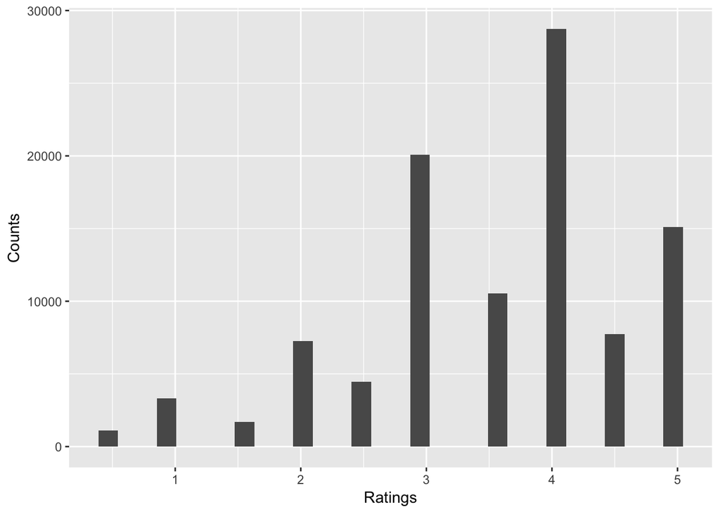

```r
# plot distribution of ratings
ggplot(data=ratings, aes(x=rating), aplha=0.8) + geom_histogram() + xlab('Ratings') + ylab('Counts')
```

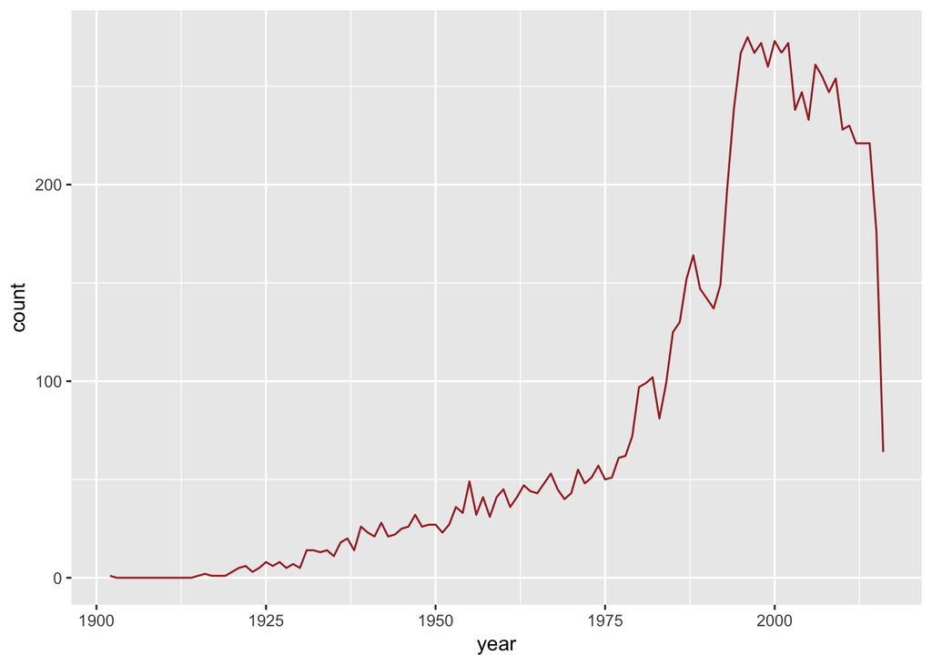

```r
# fill missing years
movies_every_year <- movies_every_year %>% complete(year = full_seq(year, 1), fill = list(count = 0))
#we plot the number of movies for every year and we can observe a clear increase in the movies
movies_every_year %>% ggplot(aes(x = year, y = count)) + geom_line(color="brown")
```

```r
#we save the genres which are multiple in number and are separated by |
#we store the results in genres_dataframe
genres_dataframe <- movies_dataframe %>% separate_rows(genres, sep = "\\|") %>% group_by(genres) %>% summarise(number = n()) %>% arrange(desc(number))
```

```r
#we change the timestamp column to proper readable format
ratings_dataframe <- ratings %>% mutate(timestamp = as_datetime(timestamp))

#we join ratings_dataframe to movie_dataframe with movieID as key and omit na rows; then we select four columns of our interest
average_rating <- ratings_dataframe %>% inner_join(movies_dataframe, by = "movieId") %>% na.omit() %>% select(movieId, title, rating, year) %>% group_by(movieId, title, year) %>% summarise(count = n(), mean = mean(rating), min = min(rating), max = max(rating)) %>% ungroup() %>% arrange(desc(mean))

print(head(average_rating, n=20))
```

```
## # A tibble: 20 x 7
##    movieId title                              year count  mean   min   max
##      <int> <chr>                             <int> <int> <dbl> <dbl> <dbl>
##  1      53 Lamerica                           1994     1  5.00  5.00  5.00
##  2     183 Mute Witness                       1994     1  5.00  5.00  5.00
##  3     301 Picture Bride (Bijo photo)         1994     1  5.00  5.00  5.00
##  4     309 Red Firecracker, Green Firecrack…  1994     3  5.00  5.00  5.00
##  5     559 Paris, France                      1993     1  5.00  5.00  5.00
##  6     702 Faces                              1968     1  5.00  5.00  5.00
##  7     759 Maya Lin: A Strong Clear Vision    1994     2  5.00  5.00  5.00
##  8     764 Heavy                              1995     1  5.00  5.00  5.00
##  9     820 Death in the Garden (Mort en ce …  1956     1  5.00  5.00  5.00
## 10     845 Day the Sun Turned Cold, The (Ti…  1994     1  5.00  5.00  5.00
## 11     872 Vive L'Amour (Ai qing wan sui)     1994     1  5.00  5.00  5.00
## 12     876 Supercop 2 (Project S) (Chao ji …  1993     1  5.00  5.00  5.00
## 13     961 Little Lord Fauntleroy             1936     1  5.00  5.00  5.00
## 14    1312 Female Perversions                 1996     1  5.00  5.00  5.00
## 15    1420 Message to Love: The Isle of Wig…  1996     1  5.00  5.00  5.00
## 16    1428 Angel Baby                         1995     1  5.00  5.00  5.00
## 17    1450 Prisoner of the Mountains (Kavka…  1996     1  5.00  5.00  5.00
## 18    1455 Hotel de Love                      1996     1  5.00  5.00  5.00
## 19    1531 Losing Chase                       1996     1  5.00  5.00  5.00
## 20    1543 Designated Mourner, The            1997     1  5.00  5.00  5.00
```

```r
#create a function to comput the weighted rating for non personalized recommendation
# RATING = average for the movie mean
# VOTES_COUNT = count of votes for the movie
# MINIMUM_NEEDED = minimum votes required to be listed in the Top 250
# MEAN_ENTIRE = the mean vote across the entire dataset
weighted_rating_for_non_personalized <- function(RATING, VOTES_COUNT, MINIMUM_NEEDED, MEAN_ENTIRE) {
  return (VOTES_COUNT/(VOTES_COUNT+MINIMUM_NEEDED))*RATING + (MINIMUM_NEEDED/(VOTES_COUNT+MINIMUM_NEEDED))*MEAN_ENTIRE
}

#apply this function to obtain average_rating
average_rating <- average_rating %>% mutate(wr = weighted_rating_for_non_personalized(mean, count, 500, mean(mean))) %>% arrange(desc(wr))
print(head(average_rating, n=20))
```

```
## # A tibble: 20 x 8
##    movieId title                        year count  mean   min   max    wr
##      <int> <chr>                       <int> <int> <dbl> <dbl> <dbl> <dbl>
##  1     356 Forrest Gump                 1994   341  4.05 1.00   5.00 0.405
##  2     296 Pulp Fiction                 1994   324  4.26 0.500  5.00 0.393
##  3     318 Shawshank Redemption, The    1994   311  4.49 1.00   5.00 0.383
##  4     593 Silence of the Lambs, The    1991   304  4.14 0.500  5.00 0.378
##  5     260 Star Wars: Episode IV - A …  1977   291  4.22 0.500  5.00 0.368
##  6     480 Jurassic Park                1993   274  3.71 0.500  5.00 0.354
##  7    2571 Matrix, The                  1999   259  4.18 1.00   5.00 0.341
##  8       1 Toy Story                    1995   247  3.87 1.00   5.00 0.331
##  9     527 Schindler's List             1993   244  4.30 0.500  5.00 0.328
## 10     589 Terminator 2: Judgment Day   1991   237  4.01 1.00   5.00 0.322
## 11    1196 Star Wars: Episode V - The…  1980   234  4.23 0.500  5.00 0.319
## 12     110 Braveheart                   1995   228  3.95 0.500  5.00 0.313
## 13    1270 Back to the Future           1985   226  4.02 1.00   5.00 0.311
## 14     608 Fargo                        1996   224  4.26 1.00   5.00 0.309
## 15    2858 American Beauty              1999   220  4.24 0.500  5.00 0.306
## 16    1198 Raiders of the Lost Ark (I…  1981   220  4.19 0.500  5.00 0.306
## 17     780 Independence Day (a.k.a. I…  1996   218  3.48 0.500  5.00 0.304
## 18    1210 Star Wars: Episode VI - Re…  1983   217  4.06 0.500  5.00 0.303
## 19     588 Aladdin                      1992   215  3.67 0.500  5.00 0.301
## 20     457 Fugitive, The                1993   213  3.95 0.500  5.00 0.299
```